# Assignment 1 - modelling of census income

```python
import pyspark
import databricks.koalas as ks
```

```python
import seaborn as sns
import matplotlib.pyplot as plt
import numpy as np
import pandas as pd
from pyspark.sql import SparkSession
import warnings
warnings.filterwarnings('ignore')
```

```python
from sklearn.metrics import roc_curve, auc
from sklearn.metrics import roc_auc_score
```

```python
def detect_types(data):
    numerical_preds=[]
    categorical_preds=[]


    for i in list(data):
        if(data[i].dtype=='object'):
            categorical_preds.append(i)
        else:
            numerical_preds.append(i)

    return numerical_preds,categorical_preds


def comp_auc(target, predictions):
    return roc_auc_score(target, predictions)


def graph_exploration_cat(feature_binned,target):

    '''
    if(sum(feature_binned.isnull())>0):
        feature_binned=feature_binned.cat.add_categories('NA').fillna('NA')
    '''

    result = ks.concat([feature_binned, target], axis=1)
    tg_mn=target.mean()

    gb=result.groupby(feature_binned)
    counts = gb.size().to_frame(name='counts')
    final=counts.join(gb.agg({result.columns[1]: 'mean'}).rename(columns={result.columns[1]: 'target_mean'})).reset_index()

    final=final.to_pandas()
    # We are fine to use pandas here, because 'final' table will be always small with some aggregations only
    final['odds_ratio']=np.log2((final['counts']*final['target_mean']+100*tg_mn)/((100+final['counts'])*tg_mn))


    sns.set(rc={'figure.figsize':(15,10)})
    fig, ax =plt.subplots(2,1)
    sns.barplot(x=final.columns[0],y='counts',data=final,color="blue",ax=ax[0])
    ax[0].xaxis.set_visible(False)
    sns.barplot(x=final.columns[0],y='odds_ratio',data=final,color="green",ax=ax[1])
    plt.xticks(rotation=35)
    plt.show()

def graph_exploration_num(feature_binned,target):

    if(sum(feature_binned.isnull())>0):
        feature_binned=feature_binned.cat.add_categories('NA').fillna('NA')

    result = pd.concat([feature_binned, target], axis=1)

    gb=result.groupby(feature_binned)
    counts = gb.size().to_frame(name='counts')
    final=counts.join(gb.agg({result.columns[1]: 'mean'}).rename(columns={result.columns[1]: 'target_mean'})).reset_index()
    final['odds_ratio']=np.log2((final['counts']*final['target_mean']+100*np.mean(target))/((100+final['counts'])*np.mean(target)))

    sns.set(rc={'figure.figsize':(15,10)})
    fig, ax =plt.subplots(2,1)
    sns.countplot(x=feature_binned, hue=target, data=result,ax=ax[0])
    sns.barplot(x=final.columns[0],y='odds_ratio',data=final,color="green",ax=ax[1])
    plt.show()

def replace_categories(data, categorical_preds, num_categories):
    for i in categorical_preds:
        if data[i].nunique()>num_categories:
            print(i)
            print(data[i].nunique())
            top_n_cat=data[i].value_counts()[:num_categories].to_pandas().index.tolist()


            def f(row):
                if row in top_n_cat:
                    val = row
                else:
                    val = 'other'
                return val


            data[i]=data[i].apply(f)

            #data[i]=data[i].apply(lambda x: data[i] if x in top_n_cat  else 'other')

            #data[i]=np.where(data[i].isin(top_n_cat),data[i],'other')
    return data
```

```python
data_ks=ks.read_csv(r"C:\Users\lubor.pacak\Desktop\zeta\assignment1\census-income.data",sep=',')
```

```python
data_ks['target']=data_ks['income_50k'].apply(lambda x: 0 if x==' - 50000.' else 1)
data_ks=data_ks.drop('income_50k', axis=1)
```

```python
print('Number of rows in data:')
print(data_ks.shape[0])

print('Number of columns in data:')
print(data_ks.shape[1])
```

```
Number of rows in data:
199523
Number of columns in data:
42
```

```python
numerical_preds,categorical_preds = detect_types(data_ks)
numerical_preds.remove('target')
```

Decription of numerical features:

```python
data_ks[numerical_preds].describe()
```

|  | age | det_ind_code | det_occ_code | wage_per_hour | capital_gains | capital_losses | stock_dividends | unknown_col | num_emp | own_or_self | vet_benefits | weeks_worked | year |
| --- | --- | --- | --- | --- | --- | --- | --- | --- | --- | --- | --- | --- | --- |
| count | 199523.000000 | 199523.000000 | 199523.000000 | 199523.000000 | 199523.00000 | 199523.000000 | 199523.000000 | 199523.000000 | 199523.000000 | 199523.000000 | 199523.000000 | 199523.000000 | 199523.000000 |
| mean | 34.494204 | 15.352320 | 11.306556 | 55.426908 | 434.71899 | 37.313788 | 197.529533 | 1740.380269 | 1.956180 | 0.175438 | 1.514833 | 23.174897 | 94.499672 |
| std | 22.310904 | 18.067129 | 14.454204 | 274.896454 | 4697.53128 | 271.896428 | 1984.163658 | 993.768156 | 2.365126 | 0.553694 | 0.851473 | 24.411488 | 0.500001 |
| min | 0.000000 | 0.000000 | 0.000000 | 0.000000 | 0.00000 | 0.000000 | 0.000000 | 37.870000 | 0.000000 | 0.000000 | 0.000000 | 0.000000 | 94.000000 |
| 25% | 15.000000 | 0.000000 | 0.000000 | 0.000000 | 0.00000 | 0.000000 | 0.000000 | 1061.570000 | 0.000000 | 0.000000 | 2.000000 | 0.000000 | 94.000000 |
| 50% | 33.000000 | 0.000000 | 0.000000 | 0.000000 | 0.00000 | 0.000000 | 0.000000 | 1618.180000 | 1.000000 | 0.000000 | 2.000000 | 8.000000 | 94.000000 |
| 75% | 50.000000 | 33.000000 | 26.000000 | 0.000000 | 0.00000 | 0.000000 | 0.000000 | 2188.340000 | 4.000000 | 0.000000 | 2.000000 | 52.000000 | 95.000000 |
| max | 90.000000 | 51.000000 | 46.000000 | 9999.000000 | 99999.00000 | 4608.000000 | 99999.000000 | 18656.300000 | 6.000000 | 2.000000 | 2.000000 | 52.000000 | 95.000000 |

Number of unique categories of categorical features:

```python
data_ks[categorical_preds].nunique()
```

```
class_worker         9
education           17
hs_college           3
marital_stat         7
major_ind_code      24
major_occ_code      15
race                 5
hisp_origin         10
sex                  2
union_member         3
unemp_reason         6
full_or_part_emp     8
tax_filer_stat       6
region_prev_res      6
state_prev_res      51
det_hh_fam_stat     38
det_hh_summ          8
mig_chg_msa         10
mig_chg_reg          9
mig_move_reg        10
mig_same             3
mig_prev_sunbelt     4
fam_under_18         5
country_father      43
country_mother      43
country_self        43
citizenship          5
vet_question         3
Name: 0, dtype: int64
```

Few categorical features have lot of categories (10+), which is usually not so much useful for modelling purposes. I Will convert variables with more than 7 categories to 7 most populated and one last which will represent all other categories as 'other' category.

```python
data_ks = replace_categories(data_ks, categorical_preds, 7)
```

```
class_worker
9
education
17
major_ind_code
24
major_occ_code
15
hisp_origin
10
full_or_part_emp
8
state_prev_res
51
det_hh_fam_stat
38
det_hh_summ
8
mig_chg_msa
10
mig_chg_reg
9
mig_move_reg
10
country_father
43
country_mother
43
country_self
43
```

### Target exploration

```
0    0.937942
1    0.062058
Name: target, dtype: float64
```

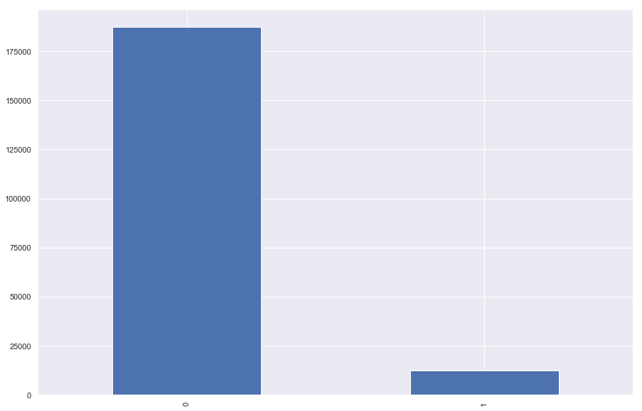

```python
data_ks['target'].value_counts().plot(kind='bar')
data_ks['target'].value_counts()/data_ks.shape[0]
```

# Explanatory data analysis of categorical variables

Odds_ratio means log2 of ratio of target rate within given category and total target rate of dataset. For Example, when target rate in dataset is 0.05 and target rate within particular category is 0.1, than odds_ratio = log2(0.1/0.05)=1.

```
class_worker
```

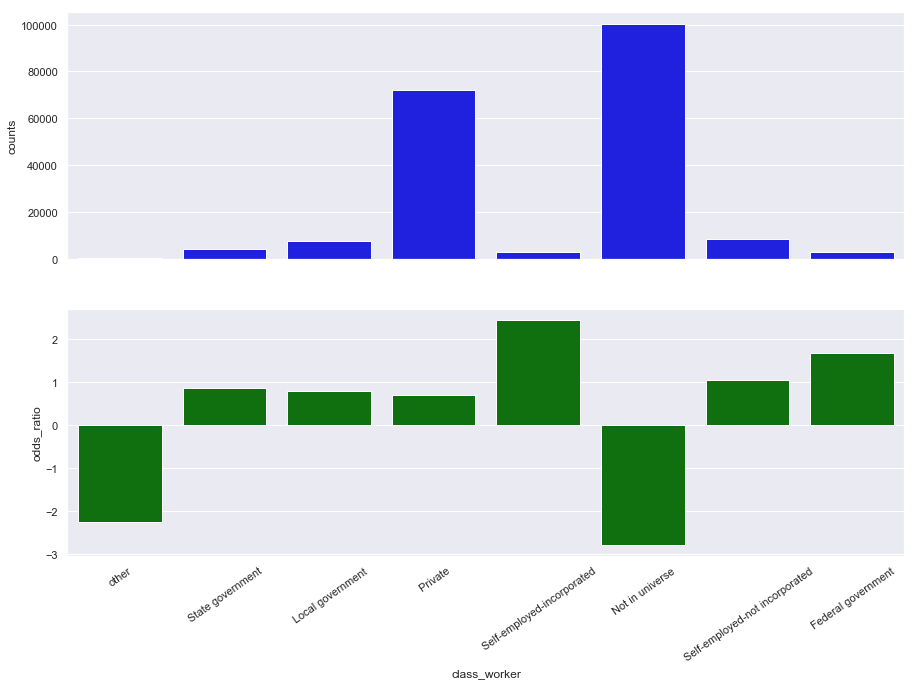

```
--------------------------------------------------------------------------------------------------------------
--------------------------------------------------------------------------------------------------------------
education
```

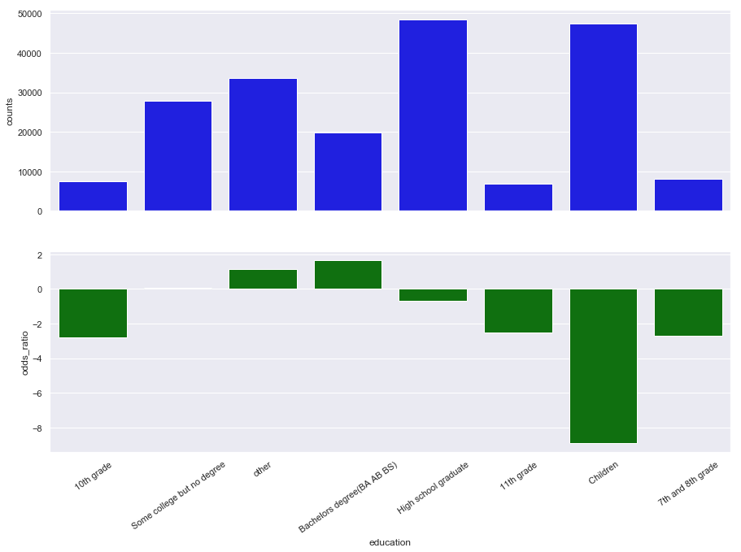

```
--------------------------------------------------------------------------------------------------------------
--------------------------------------------------------------------------------------------------------------
hs_college
```

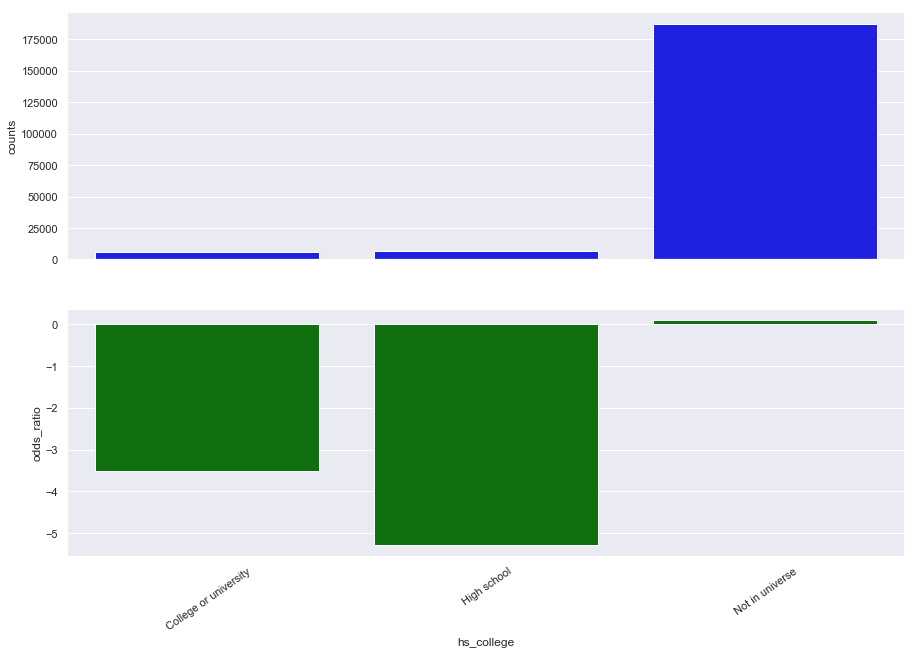

```
--------------------------------------------------------------------------------------------------------------
--------------------------------------------------------------------------------------------------------------
marital_stat
```

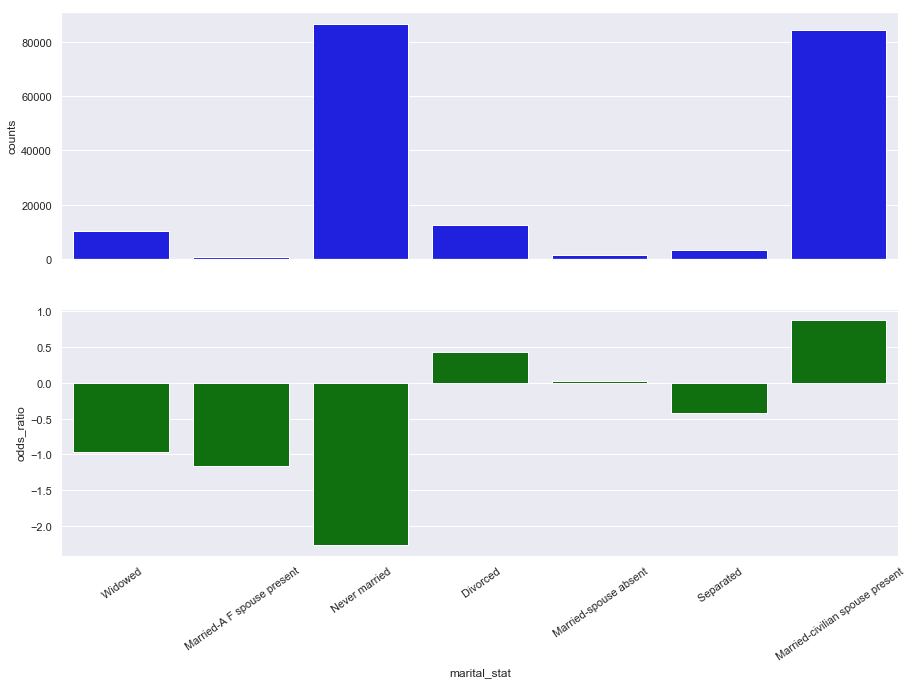

```
--------------------------------------------------------------------------------------------------------------
--------------------------------------------------------------------------------------------------------------
major_ind_code
```

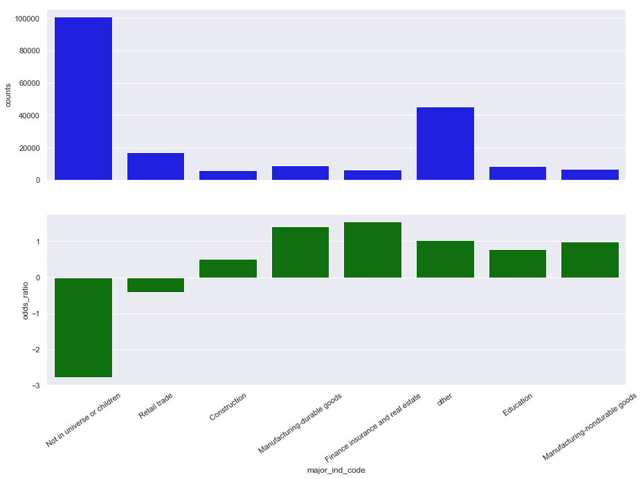

```
--------------------------------------------------------------------------------------------------------------
--------------------------------------------------------------------------------------------------------------
major_occ_code
```

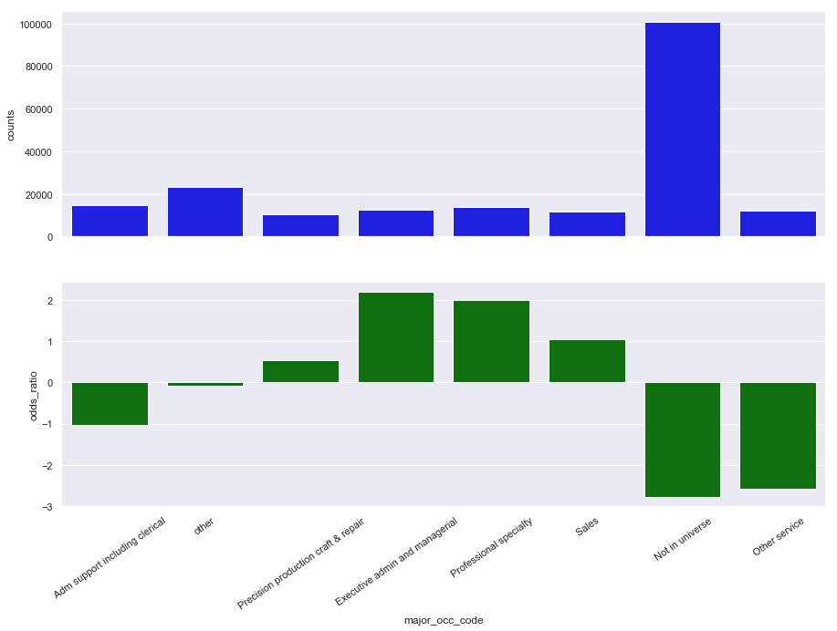

```
--------------------------------------------------------------------------------------------------------------
--------------------------------------------------------------------------------------------------------------
race
```

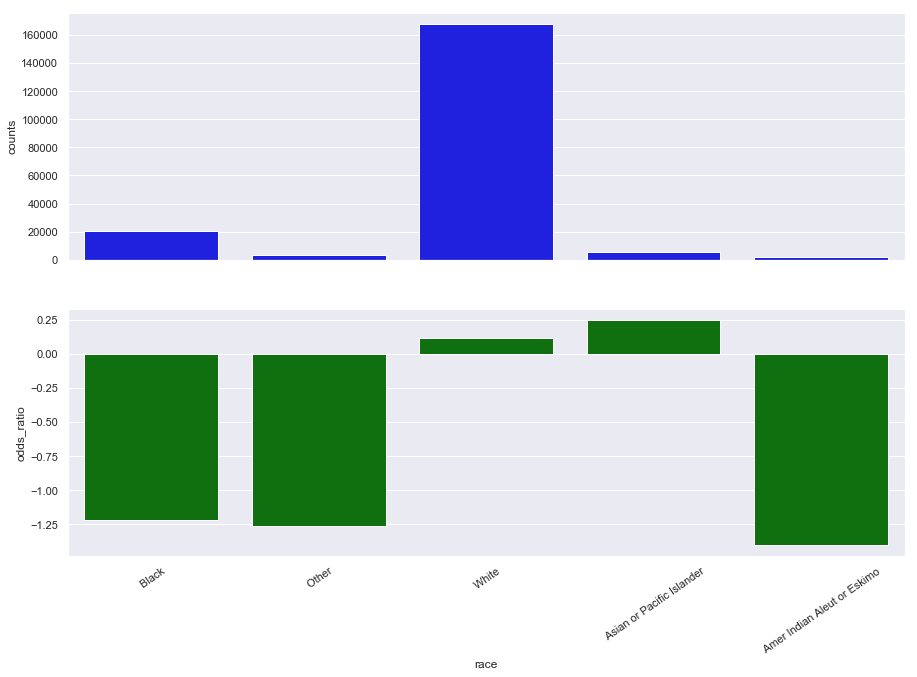

```
--------------------------------------------------------------------------------------------------------------
--------------------------------------------------------------------------------------------------------------
hisp_origin
```

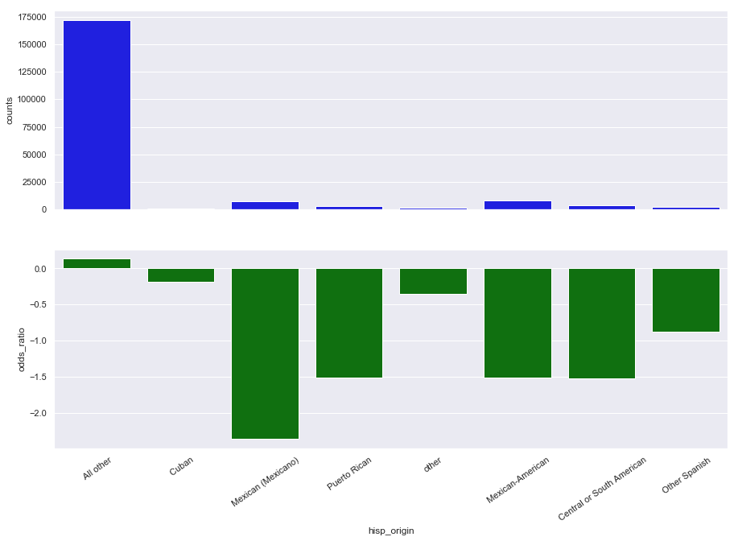

```
--------------------------------------------------------------------------------------------------------------
--------------------------------------------------------------------------------------------------------------
sex
```

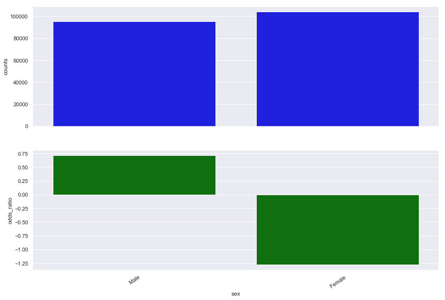

```
--------------------------------------------------------------------------------------------------------------
--------------------------------------------------------------------------------------------------------------
union_member
```

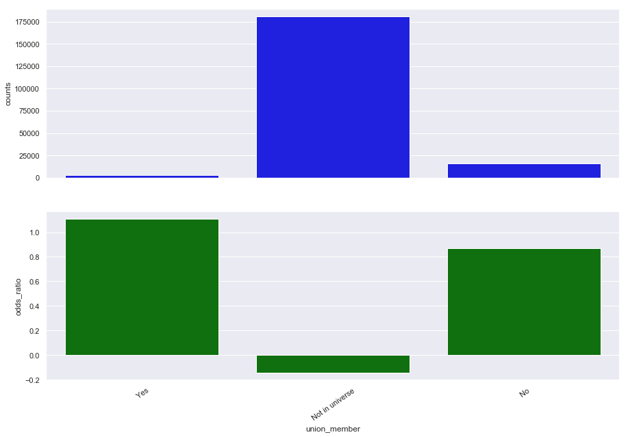

```
--------------------------------------------------------------------------------------------------------------
--------------------------------------------------------------------------------------------------------------
unemp_reason
```

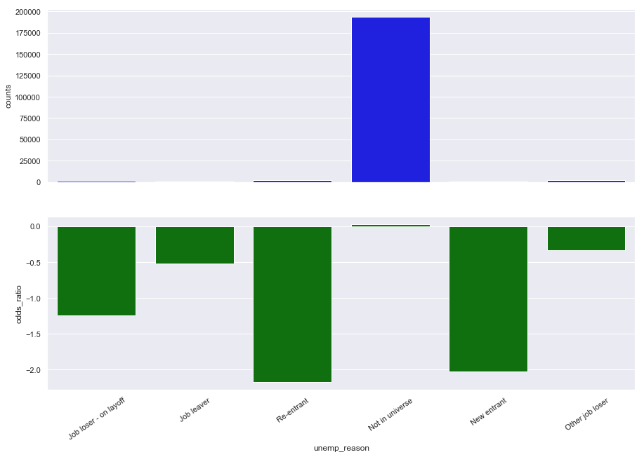

```
--------------------------------------------------------------------------------------------------------------
--------------------------------------------------------------------------------------------------------------
full_or_part_emp
```

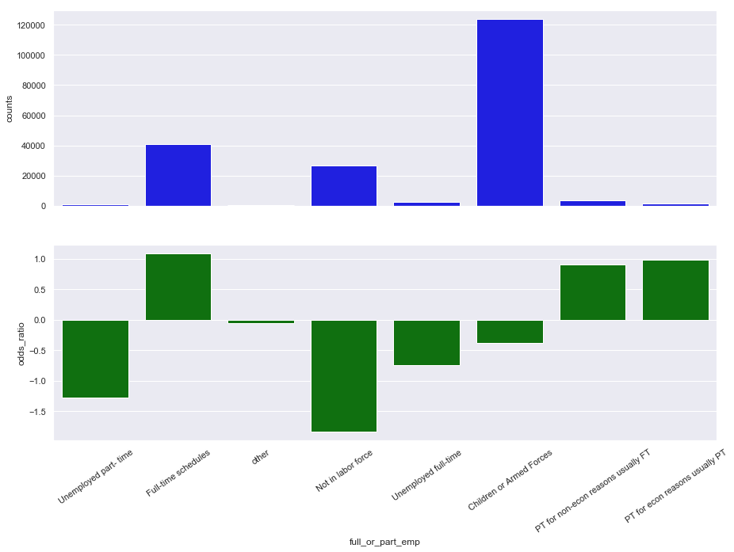

```
--------------------------------------------------------------------------------------------------------------
--------------------------------------------------------------------------------------------------------------
tax_filer_stat
```

[16 more figures not shown]

```python
for i in categorical_preds:
    print(i)

    graph_exploration_cat(data_ks[i],data_ks['target'])

    print('--------------------------------------------------------------------------------------------------------------')
    print('--------------------------------------------------------------------------------------------------------------')
```

# Observations from EDA of categorical variables

- Powerfull predictors seems to be Sex, where men are much more likely to have higher salary than women.
- Education looks also as the strong predictor, where 'bachelor' (university degrees) and 'other' categorie seems to have higher salary. On the other hand 'children' category is widely populated with very low target rate.
- Major industry code seems to be also Major industry code where 'Not in universe' seems to be highly agains the target.

Useless predictors seems to be: unemp_reason, region_prev_res, mig_chg_reg, citizenship, mig_prev_sunbelt, mig_chg_msa, mig_same, mig_move_reg, union_member, vet_question, hisp_origin

# Explanatory data analysis of numerical variables

```
age
SAME FREQUENCY BINNING:
```

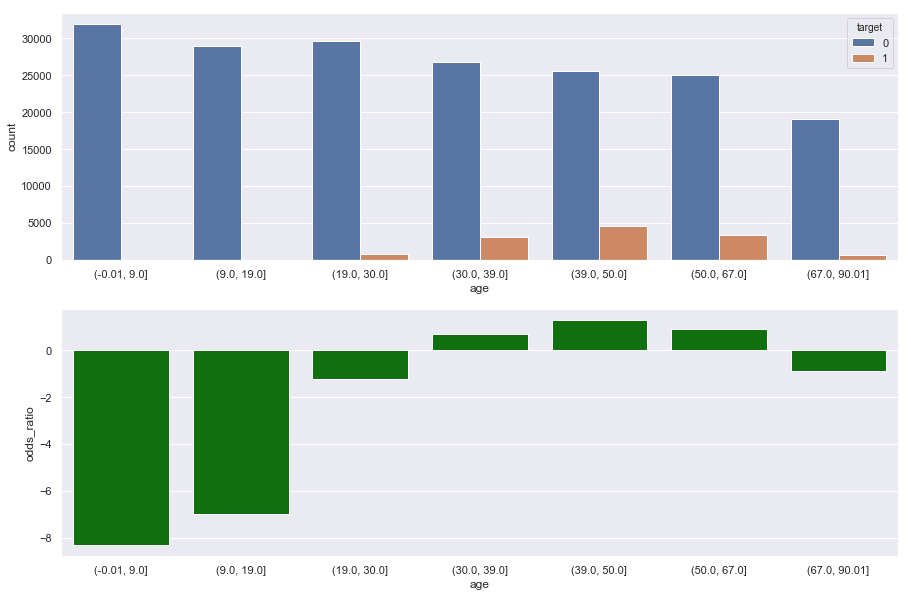

```
AUC of this variable:
0.694
---------------------------------------------------------
---------------------------------------------------------
 det_ind_code
SAME FREQUENCY BINNING:
```

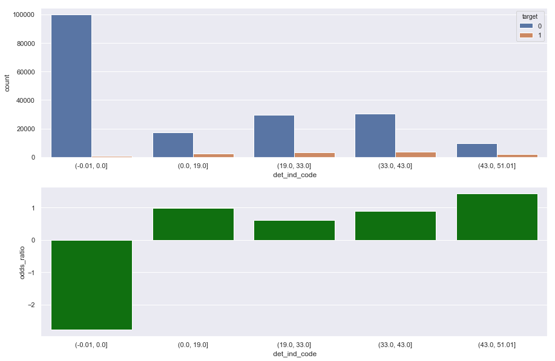

```
AUC of this variable:
0.738
---------------------------------------------------------
---------------------------------------------------------
 det_occ_code
SAME FREQUENCY BINNING:
```

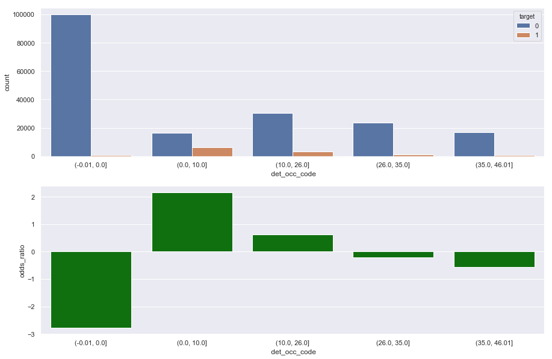

```
AUC of this variable:
0.627
---------------------------------------------------------
---------------------------------------------------------
 wage_per_hour
SAME FREQUENCY BINNING:
```

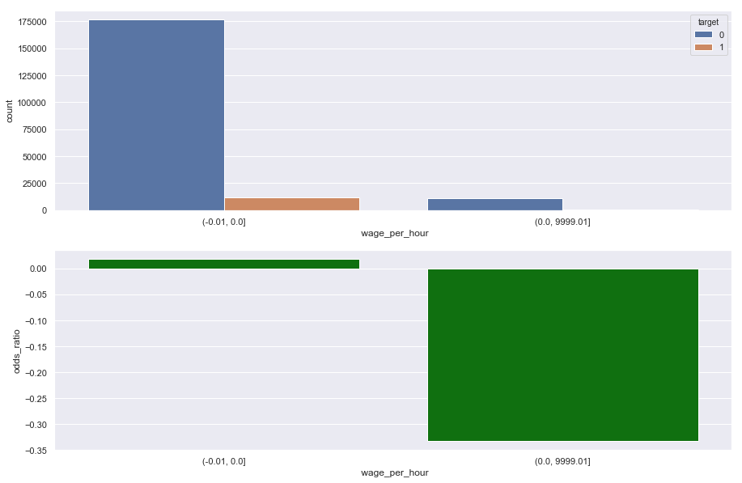

```
AUC of this variable:
0.505
---------------------------------------------------------
---------------------------------------------------------
 capital_gains
SAME FREQUENCY BINNING:
```

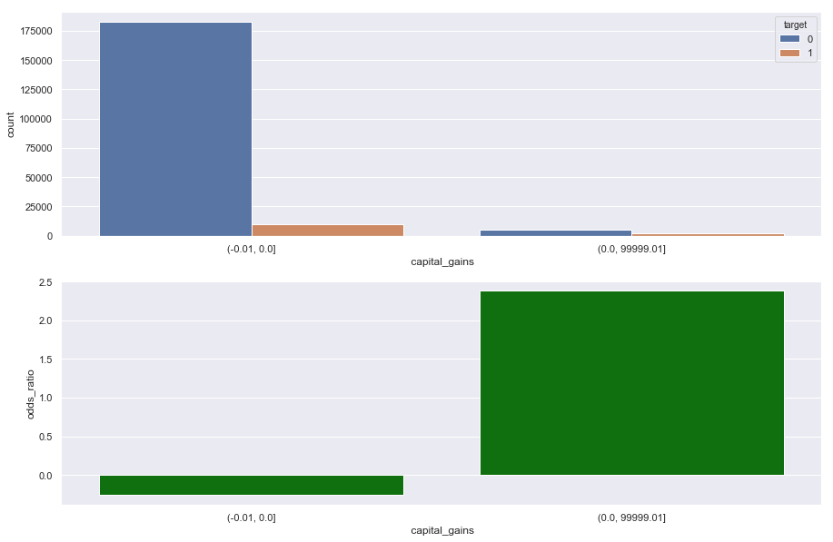

```
AUC of this variable:
0.586
---------------------------------------------------------
---------------------------------------------------------
 capital_losses
SAME FREQUENCY BINNING:
```

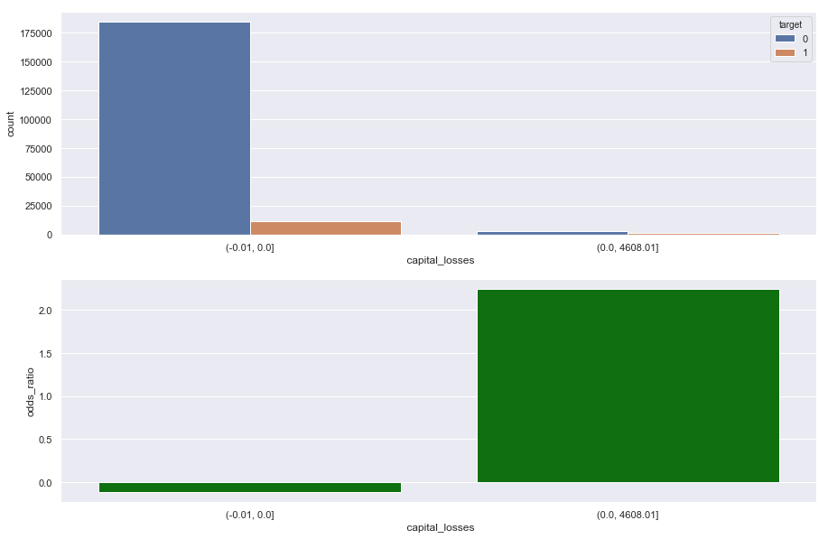

```
AUC of this variable:
0.54
---------------------------------------------------------
---------------------------------------------------------
 stock_dividends
SAME FREQUENCY BINNING:
```

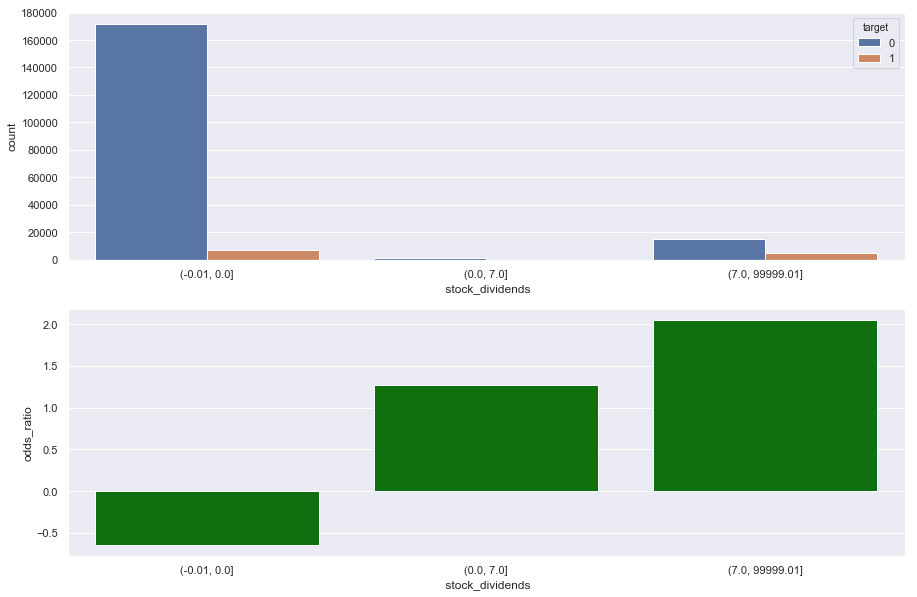

```
AUC of this variable:
0.676
---------------------------------------------------------
---------------------------------------------------------
 unknown_col
SAME FREQUENCY BINNING:
```

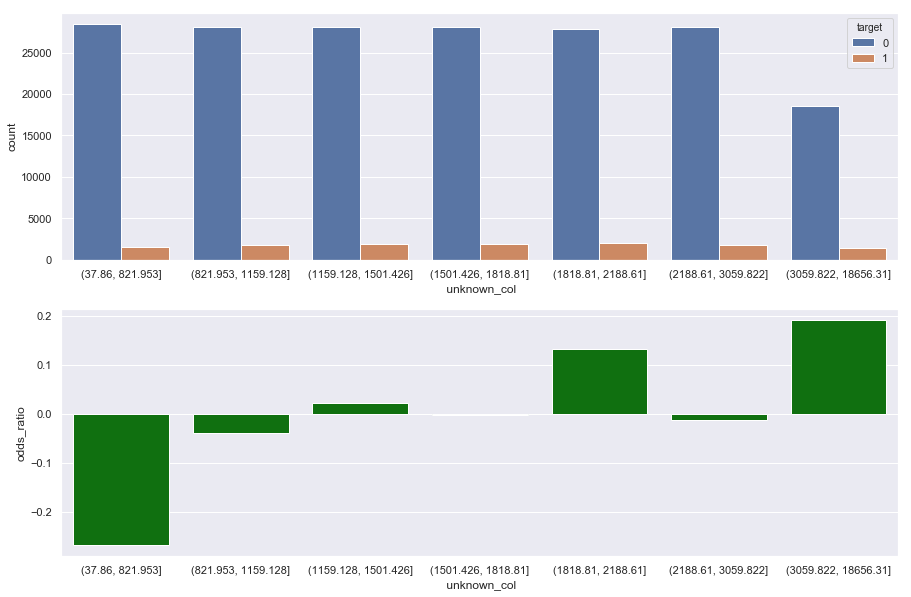

```
AUC of this variable:
0.522
---------------------------------------------------------
---------------------------------------------------------
 num_emp
SAME FREQUENCY BINNING:
```

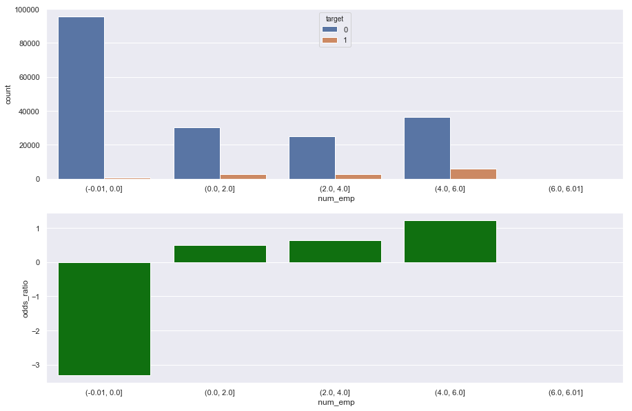

```
AUC of this variable:
0.764
---------------------------------------------------------
---------------------------------------------------------
 own_or_self
SAME FREQUENCY BINNING:
```

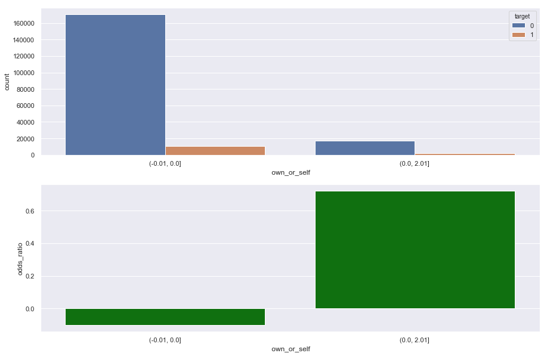

```
AUC of this variable:
0.531
---------------------------------------------------------
---------------------------------------------------------
 vet_benefits
SAME FREQUENCY BINNING:
```

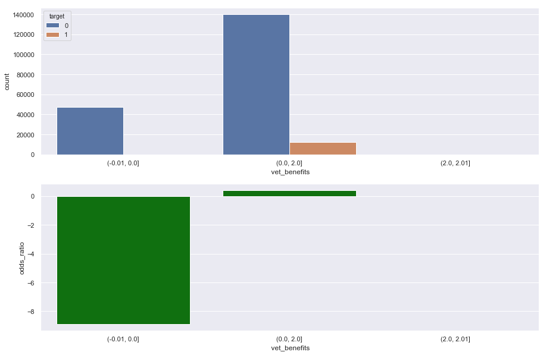

```
AUC of this variable:
0.624
---------------------------------------------------------
---------------------------------------------------------
 weeks_worked
SAME FREQUENCY BINNING:
```

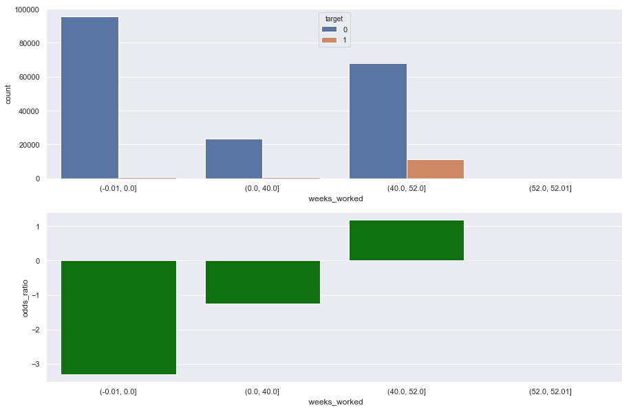

```
AUC of this variable:
0.788
---------------------------------------------------------
---------------------------------------------------------
 year
SAME FREQUENCY BINNING:
```

[1 more figures not shown]

```
AUC of this variable:
0.515
---------------------------------------------------------
---------------------------------------------------------
```

```python
for i in numerical_preds:
    print(i)
    data=data_ks[[i,'target']].to_pandas()

    print('SAME FREQUENCY BINNING:')

    borders=[]
    for j in [15,30,45,60,75,90]:
        borders=np.append(borders,np.nanpercentile(data[i],j))
    borders=np.concatenate(([data[i].min()-0.01], borders))
    borders=np.append(borders,data[i].max()+0.01)
    borders=list(dict.fromkeys(borders))
    graph_exploration_num(pd.cut(data[i],borders),data['target'])


    print('AUC of this variable:')
    auc=comp_auc(data['target'], data[i])
    if auc > 0.5:
        print(round(auc,3))
    else:
        print(round(1-auc,3))


    print('---------------------------------------------------------')
    print('---------------------------------------------------------')
```

Useless predictors seems to be: year, own_or_self, unknown_col

```python
data_ks.head()
```

|  | age | class_worker | det_ind_code | det_occ_code | education | wage_per_hour | hs_college | marital_stat | major_ind_code | major_occ_code | race | hisp_origin | sex | union_member | unemp_reason | full_or_part_emp | capital_gains | capital_losses | stock_dividends | tax_filer_stat | region_prev_res | state_prev_res | det_hh_fam_stat | det_hh_summ | unknown_col | mig_chg_msa | mig_chg_reg | mig_move_reg | mig_same | … |
| --- | --- | --- | --- | --- | --- | --- | --- | --- | --- | --- | --- | --- | --- | --- | --- | --- | --- | --- | --- | --- | --- | --- | --- | --- | --- | --- | --- | --- | --- | --- |
| 0 | 74 | Not in universe | 0.0 | 0.0 | High school graduate | 0.0 | Not in universe | Widowed | Not in universe or children | Not in universe | White | All other | Female | Not in universe | Not in universe | Not in labor force | 0.0 | 0.0 | 0.0 | Nonfiler | Not in universe | Not in universe | Other Rel 18+ ever marr not in subfamily | Other relative of householder | 1700.09 | ? | ? | ? | Not in universe under 1 year old | … |
| 1 | 58 | Self-employed-not incorporated | 4.0 | 34.0 | Some college but no degree | 0.0 | Not in universe | Divorced | Construction | Precision production craft & repair | White | All other | Male | Not in universe | Not in universe | Children or Armed Forces | 0.0 | 0.0 | 0.0 | Head of household | South | other | Householder | Householder | 1053.55 | MSA to MSA | Same county | Same county | No | … |
| 2 | 18 | Not in universe | 0.0 | 0.0 | 10th grade | 0.0 | High school | Never married | Not in universe or children | Not in universe | Asian or Pacific Islander | All other | Female | Not in universe | Not in universe | Not in labor force | 0.0 | 0.0 | 0.0 | Nonfiler | Not in universe | Not in universe | Child 18+ never marr Not in a subfamily | Child 18 or older | 991.95 | ? | ? | ? | Not in universe under 1 year old | … |
| 3 | 9 | Not in universe | 0.0 | 0.0 | Children | 0.0 | Not in universe | Never married | Not in universe or children | Not in universe | White | All other | Female | Not in universe | Not in universe | Children or Armed Forces | 0.0 | 0.0 | 0.0 | Nonfiler | Not in universe | Not in universe | Child <18 never marr not in subfamily | Child under 18 never married | 1758.14 | Nonmover | Nonmover | Nonmover | Yes | … |
| 4 | 10 | Not in universe | 0.0 | 0.0 | Children | 0.0 | Not in universe | Never married | Not in universe or children | Not in universe | White | All other | Female | Not in universe | Not in universe | Children or Armed Forces | 0.0 | 0.0 | 0.0 | Nonfiler | Not in universe | Not in universe | Child <18 never marr not in subfamily | Child under 18 never married | 1069.16 | Nonmover | Nonmover | Nonmover | Yes | … |

## Preparation for modelling

Now I will switch from koalas dataframe to the spark dataframe.

```python
spark_df=data_ks.to_spark()
```

```python
spark_df.printSchema()
```

```
root
 |-- age: integer (nullable = true)
 |-- class_worker: string (nullable = true)
 |-- det_ind_code: double (nullable = true)
 |-- det_occ_code: double (nullable = true)
 |-- education: string (nullable = true)
 |-- wage_per_hour: double (nullable = true)
 |-- hs_college: string (nullable = true)
 |-- marital_stat: string (nullable = true)
 |-- major_ind_code: string (nullable = true)
 |-- major_occ_code: string (nullable = true)
 |-- race: string (nullable = true)
 |-- hisp_origin: string (nullable = true)
 |-- sex: string (nullable = true)
 |-- union_member: string (nullable = true)
 |-- unemp_reason: string (nullable = true)
 |-- full_or_part_emp: string (nullable = true)
 |-- capital_gains: double (nullable = true)
 |-- capital_losses: double (nullable = true)
 |-- stock_dividends: double (nullable = true)
 |-- tax_filer_stat: string (nullable = true)
 |-- region_prev_res: string (nullable = true)
 |-- state_prev_res: string (nullable = true)
 |-- det_hh_fam_stat: string (nullable = true)
 |-- det_hh_summ: string (nullable = true)
 |-- unknown_col: double (nullable = true)
 |-- mig_chg_msa: string (nullable = true)
 |-- mig_chg_reg: string (nullable = true)
 |-- mig_move_reg: string (nullable = true)
 |-- mig_same: string (nullable = true)
 |-- mig_prev_sunbelt: string (nullable = true)
 |-- num_emp: double (nullable = true)
 |-- fam_under_18: string (nullable = true)
 |-- country_father: string (nullable = true)
 |-- country_mother: string (nullable = true)
 |-- country_self: string (nullable = true)
 |-- citizenship: string (nullable = true)
 |-- own_or_self: double (nullable = true)
 |-- vet_question: string (nullable = true)
 |-- vet_benefits: double (nullable = true)
 |-- weeks_worked: double (nullable = true)
 |-- year: double (nullable = true)
 |-- target: long (nullable = true)
```

- Note: After some iterations of model fitting, i threw away some features because they did not bring additional power to the model. Final features used in the model are:

```python
categorical_preds=['class_worker', 'education', 'hs_college', 'marital_stat', 'major_ind_code', 'major_occ_code', 'race', 'sex', 'full_or_part_emp', 'tax_filer_stat',
 'state_prev_res', 'det_hh_fam_stat', 'det_hh_summ', 'fam_under_18', 'country_father', 'country_mother', 'country_self']
```

```python
numerical_preds=['age', 'det_ind_code', 'det_occ_code', 'wage_per_hour', 'capital_gains', 'capital_losses',
 'stock_dividends', 'num_emp', 'vet_benefits', 'weeks_worked']
```

#### Preparing pyspark dataframe formodelling. The stepst are as following

1. Convert categorical variables to one-hot encoding
2. Join them with numerical variables to one columns together
3. Common column called features is suitable source for pyspark ml library

```python
from pyspark.ml.feature import OneHotEncoder, StringIndexer, VectorAssembler

stages = []
for categoricalCol in categorical_preds:
    stringIndexer = StringIndexer(inputCol = categoricalCol, outputCol = categoricalCol + 'Index')
    encoder = OneHotEncoder(inputCols=[stringIndexer.getOutputCol()], outputCols=[categoricalCol + "classVec"])
    stages += [stringIndexer, encoder]
label_stringIdx = StringIndexer(inputCol = 'target', outputCol = 'label')
stages += [label_stringIdx]
assemblerInputs = [c + "classVec" for c in categorical_preds] + numerical_preds
assembler = VectorAssembler(inputCols=assemblerInputs, outputCol="features")
stages += [assembler]
```

ml pipeline fulfills previous preparations

```python
from pyspark.ml import Pipeline

pipeline = Pipeline(stages = stages)
pipelineModel = pipeline.fit(spark_df)
df = pipelineModel.transform(spark_df)
selectedCols = ['label', 'features'] # + cols
df = df.select(selectedCols)
df.printSchema()
```

```
root
 |-- label: double (nullable = false)
 |-- features: vector (nullable = true)
```

```python
pd.DataFrame(df.take(5), columns=df.columns).head()
```

|  | label | features |
| --- | --- | --- |
| 0 | 0.0 | (1.0, 0.0, 0.0, 0.0, 0.0, 0.0, 0.0, 1.0, 0.0, ... |
| 1 | 0.0 | (0.0, 0.0, 1.0, 0.0, 0.0, 0.0, 0.0, 0.0, 0.0, ... |
| 2 | 0.0 | (1.0, 0.0, 0.0, 0.0, 0.0, 0.0, 0.0, 0.0, 0.0, ... |
| 3 | 0.0 | (1.0, 0.0, 0.0, 0.0, 0.0, 0.0, 0.0, 0.0, 1.0, ... |
| 4 | 0.0 | (1.0, 0.0, 0.0, 0.0, 0.0, 0.0, 0.0, 0.0, 1.0, ... |

Splitting data to train/test dataset

```python
train, test = df.randomSplit([0.7, 0.3], seed = 1234)
```

## Fitting of random forest with spark ML library

Random forest is ensemble of independently constructed decision trees. Final prediction is consequently made as average from particular trees. Fitting of decision trees requires less data preparation than for example logistic regression, where linear relationship between target and variables is demanded. For example Therefore I do not need to care much about data preprocessing right now (i am not saying, that is never necessary). Next big advantage of decion trees is that in a similar way as nonlinearity implicitely finds interactions between variables. In the linear models you will never find interactions, unless you will create them manually.

```python
from pyspark.ml.classification import RandomForestClassifier

rf = RandomForestClassifier(featuresCol = 'features', labelCol = 'label')
rfModel = rf.fit(train)
```

```python
predictions_test = rfModel.transform(test)
predictions_train = rfModel.transform(train)
```

```python
from pyspark.ml.evaluation import BinaryClassificationEvaluator

evaluator = BinaryClassificationEvaluator()
print('AUC on the test set:')
print("Test Area Under ROC: " + str(evaluator.evaluate(predictions_test, {evaluator.metricName: "areaUnderROC"})))
print('AUC on the train set:')
print("Test Area Under ROC: " + str(evaluator.evaluate(predictions_train, {evaluator.metricName: "areaUnderROC"})))
```

```
AUC on the test set:
Test Area Under ROC: 0.9055852764596792
AUC on the train set:
Test Area Under ROC: 0.9073943697648552
```

```python
evaluator = BinaryClassificationEvaluator()
print('areaUnderPR on the test set:')
print("" + str(evaluator.evaluate(predictions_test, {evaluator.metricName: "areaUnderPR"})))
print('areaUnderPR on the train set:')
print("" + str(evaluator.evaluate(predictions_train, {evaluator.metricName: "areaUnderPR"})))
```

```
areaUnderPR on the test set:
0.4454752730902533
areaUnderPR on the train set:
0.45670293718846977
```

We developed model with the performance more than AUC 0.9 which means very good sorting power.

# Further steps

Those steps would in my opinion lead to icrease of the model performance.

1. Focus on optimization of hyperparameters. Random forest have large hyperparameter that have impact to the model performance - subsample of row, subsample of columns, number of trees, maximal depth of the trees, minimal number of observations in each node, etc. Optimization of these could improve the performance.
2. Try to use different algorithm - gradient boosting model would probably bring higher performance.
3. Try some feature engineering and data preprocessing. There is lot of features that can be derived from given features. For example if the father and mother have the same country of origin, etc. Testing of new features into the model can bring additional performance.